# Hands-on - Visualizations with R

SURF Seminar: Data intensive research in practice: An introduction

Marc A.T. Teunis; Jan-Willem Lankhaar; Jonathan de Bruin

November 6th 2018

## Reference

https://simplystatistics.org/2018/01/22/the-dslabs-package-provides-datasets-for-teaching-data-science/

https://github.com/rbind/simplystats

[link to free online book “r4ds”:](https://r4ds.had.co.nz/) “R for Data Science”, Hadley Wickham & Garret Grolemund

## Gapminder

https://www.gapminder.org/tools/#$state$time$value=2018;;&chart-type=bubbles

## ggplot2

The ggplot2 package in R is the best plotting system for R. It’s syntax is an implementation of the ‘grammar of graphics’ and all plots in this demo are created by using ggplot2.

[figure not shown]

## Citations

```r
citation(package = "ggplot2")
```

```
##
##
##   H. Wickham. ggplot2: Elegant Graphics for Data Analysis.
##   Springer-Verlag New York, 2016.
##
## A BibTeX entry for LaTeX users is
##
##   @Book{,
##     author = {Hadley Wickham},
##     title = {ggplot2: Elegant Graphics for Data Analysis},
##     publisher = {Springer-Verlag New York},
##     year = {2016},
##     isbn = {978-3-319-24277-4},
##     url = {https://ggplot2.tidyverse.org},
##   }
```

```r
citation(package = "tidyverse")
```

```
##
##
##   Hadley Wickham (2017). tidyverse: Easily Install and Load the
##   'Tidyverse'. R package version 1.2.1.
##   https://CRAN.R-project.org/package=tidyverse
##
## A BibTeX entry for LaTeX users is
##
##   @Manual{,
##     title = {tidyverse: Easily Install and Load the 'Tidyverse'},
##     author = {Hadley Wickham},
##     year = {2017},
##     note = {R package version 1.2.1},
##     url = {https://CRAN.R-project.org/package=tidyverse},
##   }
```

```r
citation(package = "dslabs")
```

```
##
##
##   Rafael A. Irizarry and Amy Gill (2019). dslabs: Data Science
##   Labs. R package version 0.7.0.
##   https://CRAN.R-project.org/package=dslabs
##
## A BibTeX entry for LaTeX users is
##
##   @Manual{,
##     title = {dslabs: Data Science Labs},
##     author = {Rafael A. Irizarry and Amy Gill},
##     year = {2019},
##     note = {R package version 0.7.0},
##     url = {https://CRAN.R-project.org/package=dslabs},
##   }
##
## ATTENTION: This citation information has been auto-generated from
## the package DESCRIPTION file and may need manual editing, see
## 'help("citation")'.
```

## Installing data package

```r
install.packages("dslabs")
```

## Loading the data package `{dslabs}` and other packages used

```r
library(tidyverse)
library(dslabs)
library(lubridate)
```

## Datasets included in the `{dslabs}` package

```r
data(package="dslabs") %>% print()
```

## Getting original data wrangling scripts included also in the `{dslabs}` package

```r
list.files(system.file("script", package = "dslabs"))
```

```
##  [1] "make-admissions.R"
##  [2] "make-brca.R"
##  [3] "make-brexit_polls.R"
##  [4] "make-death_prob.R"
##  [5] "make-divorce_margarine.R"
##  [6] "make-gapminder-rdas.R"
##  [7] "make-greenhouse_gases.R"
##  [8] "make-historic_co2.R"
##  [9] "make-mnist_27.R"
## [10] "make-movielens.R"
## [11] "make-murders-rda.R"
## [12] "make-na_example-rda.R"
## [13] "make-nyc_regents_scores.R"
## [14] "make-olive.R"
## [15] "make-outlier_example.R"
## [16] "make-polls_2008.R"
## [17] "make-polls_us_election_2016.R"
## [18] "make-reported_heights-rda.R"
## [19] "make-research_funding_rates.R"
## [20] "make-stars.R"
## [21] "make-temp_carbon.R"
## [22] "make-tissue-gene-expression.R"
## [23] "make-trump_tweets.R"
## [24] "make-weekly_us_contagious_diseases.R"
## [25] "save-gapminder-example-csv.R"
```

## Opening one of the scripts

```r
wrangle_files <- list.files(system.file("script", package = "dslabs"), full.names = TRUE)
wrangle_files[[1]]
```

```
## [1] "D:/Program Files/R/R-3.6.1/library/dslabs/script/make-admissions.R"
```

## Loading a specific dataset by name

```r
data("gapminder", package = "dslabs")
## ?gapminder for more info on the variables in the dataset
```

The gapminder dataset contains a number of measurements on health and income outcomes for 184 countries from 1960 to 2016. It also includes two character vectors, OECD and OPEC, with the names of OECD and OPEC countries from 2016.

## Inspecting the dataset with R

```r
gapminder <- gapminder %>% as_tibble()
gapminder %>% head(2)
```

```
## # A tibble: 2 x 9
##   country  year infant_mortality life_expectancy fertility population
##   <fct>   <int>            <dbl>           <dbl>     <dbl>      <dbl>
## 1 Albania  1960             115.            62.9      6.19    1636054
## 2 Algeria  1960             148.            47.5      7.65   11124892
## # ... with 3 more variables: gdp <dbl>, continent <fct>, region <fct>
```

```r
names(gapminder)
```

```
## [1] "country"          "year"             "infant_mortality"
## [4] "life_expectancy"  "fertility"        "population"
## [7] "gdp"              "continent"        "region"
```

## A very simple example to start with

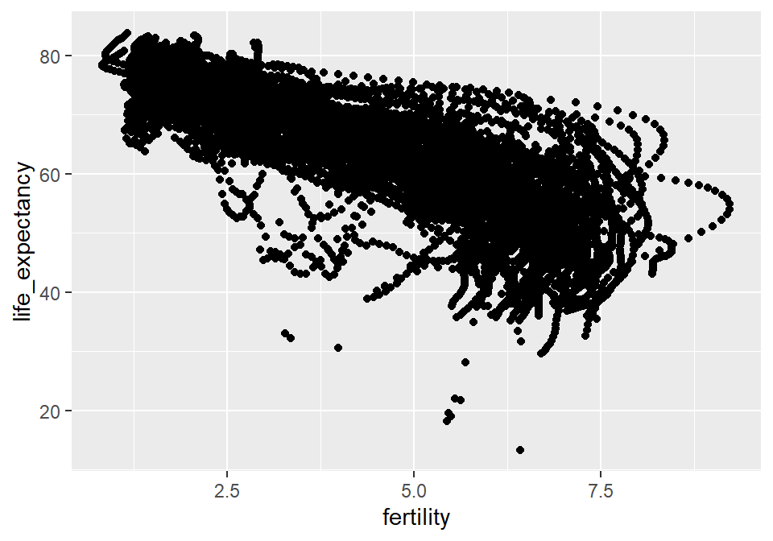

```r
gapminder %>%
  ggplot(aes(x = fertility,
             y = life_expectancy)) +
  geom_point()
```

## This is a very dense plot

We call this ‘overplotting’.

This can be fixed in several ways:

- Reducing the transparency of data points
- Mapping colour to a variable (continuous or categorical)
- Reduce the data in the plot
- Mapping a shape to a variable
- Add noise (`"jitter"`) to points
- Facetting - create panels for ‘categorical’ or so-called ‘factor’ variables in R
- Summarize the data
- Displaying a model / relationship that represents the data (and not sho the actual data itself)
- Or any combination of the above strategies

**Basically you map an `aesthetic` (`aes()`) or a `characteristic` to a variable**

Let’s go over these overplotting methods one by one

## 1. Overplotting: Reducing transparency (`alpha`) of points or lines in the data

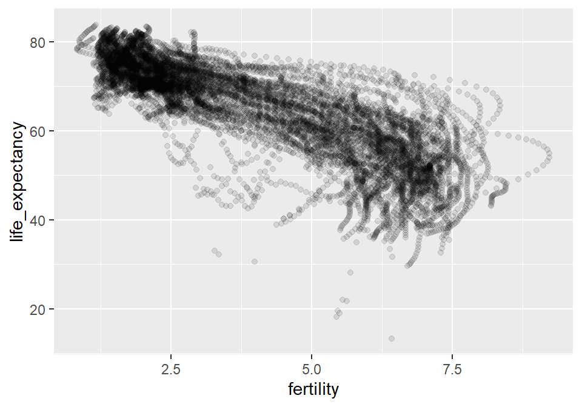

```r
gapminder %>%
  ggplot(aes(x = fertility,
             y = life_expectancy)) +
  geom_point(alpha = 0.1)
```

## 2. Mapping colour to a variable (continuous or categorical)

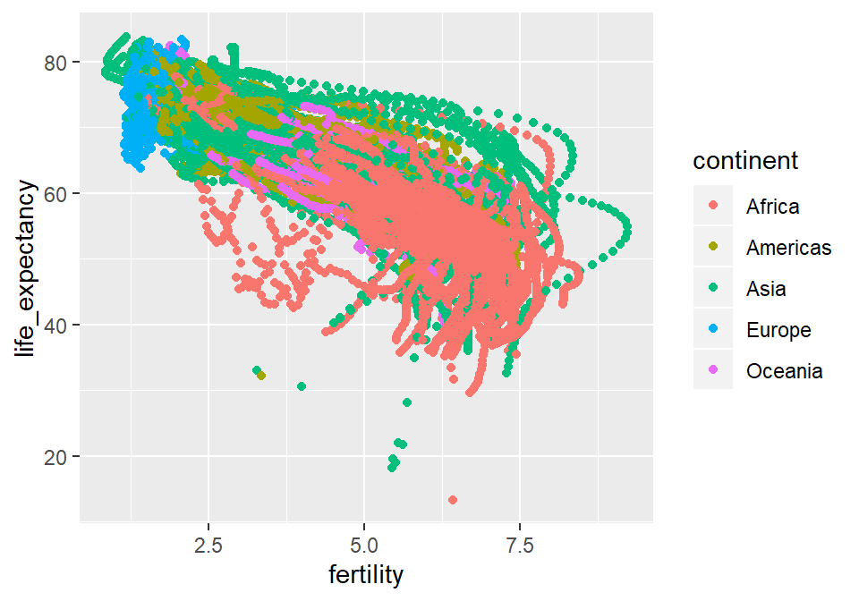

```r
gapminder %>%
  ggplot(aes(x = fertility,
             y = life_expectancy)) +
  geom_point(aes(colour = continent))
```

## or combined with `alpha`

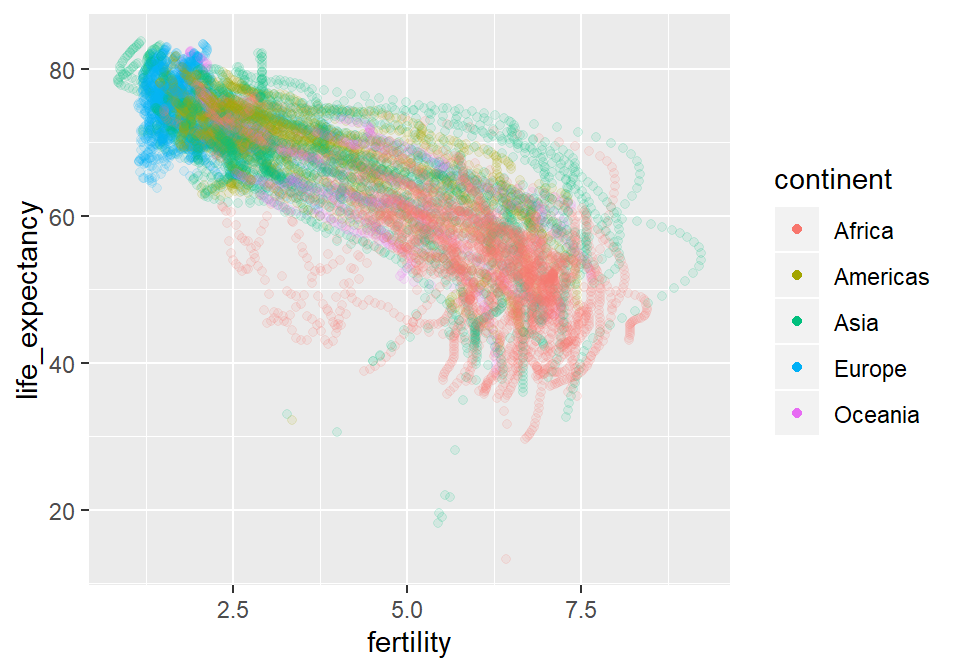

```r
gapminder %>%
  ggplot(aes(x = fertility,
             y = life_expectancy)) +
  geom_point(aes(colour = continent), alpha = 0.1) +
  guides(colour = guide_legend(override.aes = list(alpha = 1)))
```

## **Do it yourself:**

- Try adjusting some of the arguments in the previous `ggplot2` call. For example, adjust the `alpha = ...` or change the variable in `x = ...`, `y = ...` or `colour = ...`
- `names(gapminder)` gives you the variable names that you can change
- Show and discuss the resulting plot with your neighbour
- What do you think this part does:

`guides(colour = guide_legend(override.aes = list(alpha = 1)))`

- Try to find out by disabling with `#`

## 3. Reduce the data in the plot

```r
reduce_data_plot <- gapminder %>%
  filter(continent == "Africa" | continent == "Europe") %>%
  ggplot(aes(x = fertility,
             y = life_expectancy)) +
  geom_point(aes(colour = continent), alpha = 0.2) +
  ## override the alpha setting for the points in the legend:
  guides(colour = guide_legend(override.aes = list(alpha = 1)))
```

## Plot

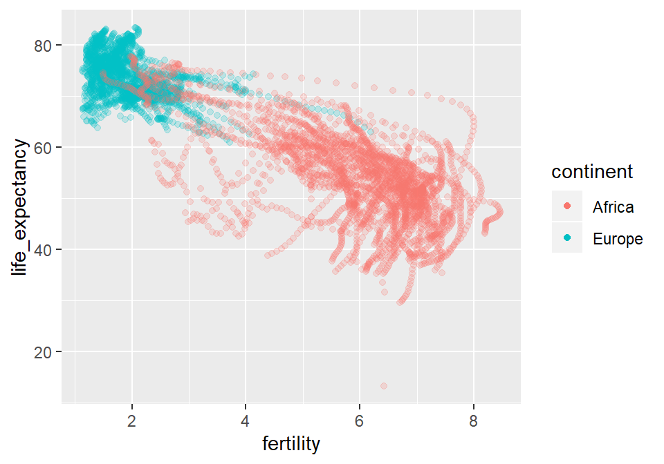

```r
reduce_data_plot
```

## **Discuss with you neighbour:**

- What does the the `aes()` part of the `geom_point()` do?
- Compare the code below with the code above, can you spot the difference, what is the advantage of the code below?

```r
reduce_data_plot <- gapminder %>%
  filter(continent == "Africa" | continent == "Europe") %>%
  ggplot(aes(x = fertility,
             y = life_expectancy, colour = continent)) +
  geom_point(alpha = 0.2) +
  ## override the alpha setting for the points in the legend:
  guides(colour = guide_legend(override.aes = list(alpha = 1)))
```

## 4. Mapping a shape to a variable

```r
## or e.g. show only two years and map a shape to continent
shape_plot <- gapminder %>%
  dplyr::filter(continent == "Africa" | continent == "Europe",
         year == "1960" | year == "2010") %>%
  ggplot(aes(x = fertility,
             y = life_expectancy)) +
  geom_point(aes(colour = as_factor(as.character(year)),
                 shape = continent),
             alpha = 0.7)
```

## **Do it youself**

- Try removing the `as_factor(as.character(year))` call and replace this by only `year` above and rerun the plot, what happened?

## Plot

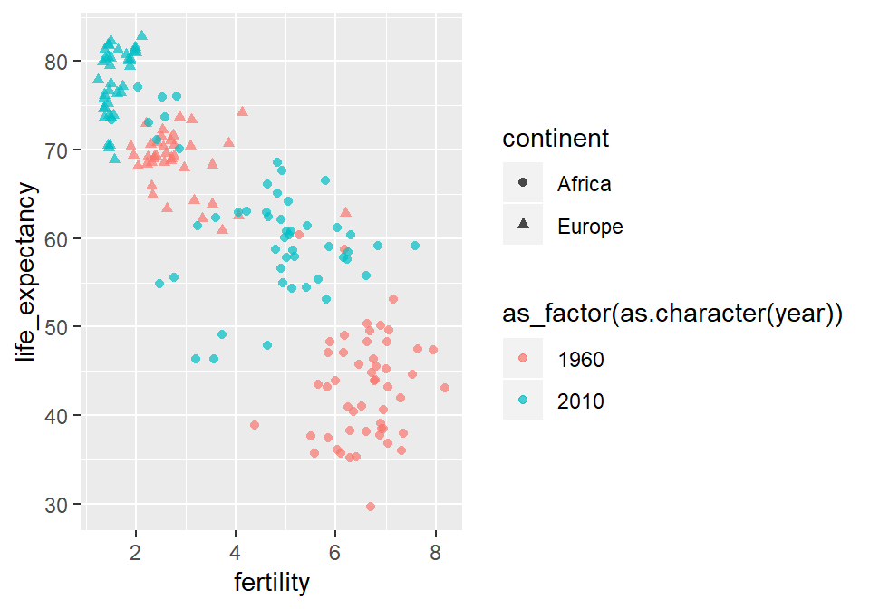

```r
shape_plot
```

## 5. Facetting

Create panels for ‘categorical’ or so-called ‘factor’ variables in R

```r
facets_plot <- gapminder %>%
  dplyr::filter(continent == "Africa" | continent == "Europe",
         year == "1960" | year == "2010") %>%
  ggplot(aes(x = fertility,
             y = life_expectancy)) +
  geom_point(aes(colour = continent), alpha = 0.5) +
  facet_wrap(~ year)
```

## Plot

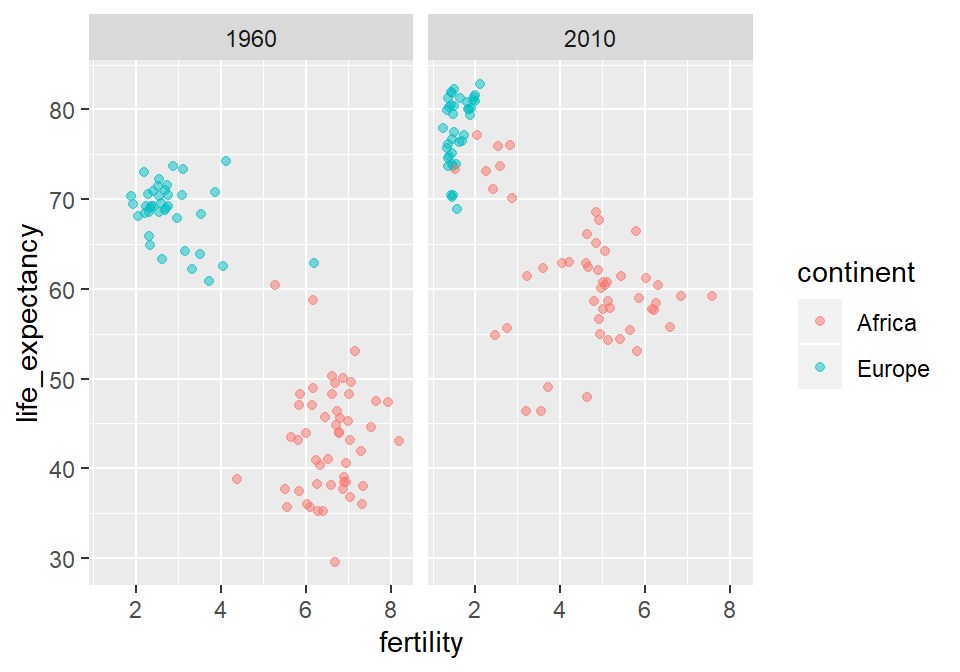

```r
facets_plot
```

## 6. Summarize the data

```r
library(ggrepel)

years <- c("1960", "1970", "1980", "1990", "2000", "2010")

summarize_plot <- gapminder %>%
  dplyr::filter(year %in% years) %>%
  group_by(continent, year) %>%
  summarise(mean_life_expectancy = mean(life_expectancy),
            mean_fertility = mean(fertility)) %>%
  ggplot(aes(x = mean_fertility,
             y = mean_life_expectancy)) +
  geom_point(aes(colour = continent), alpha = 0.7)
```

## Plot

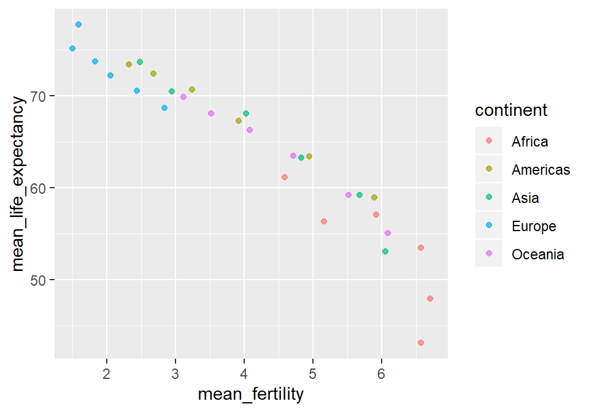

```r
summarize_plot
```

## Adding labels to the points with `{ggrepel}`

```r
library(ggrepel)

years <- c("1960", "1970", "1980", "1990", "2000", "2010")

labels_plot <- gapminder %>%
  dplyr::filter(year %in% years) %>%
  group_by(continent, year) %>%
  summarise(mean_life_expectancy = mean(life_expectancy),
            mean_fertility = mean(fertility)) %>%
  ggplot(aes(x = mean_fertility,
             y = mean_life_expectancy)) +
  geom_point(aes(colour = continent), alpha = 0.7) +
  geom_label_repel(aes(label=year), size = 2.5, box.padding = .5)
```

## Plot

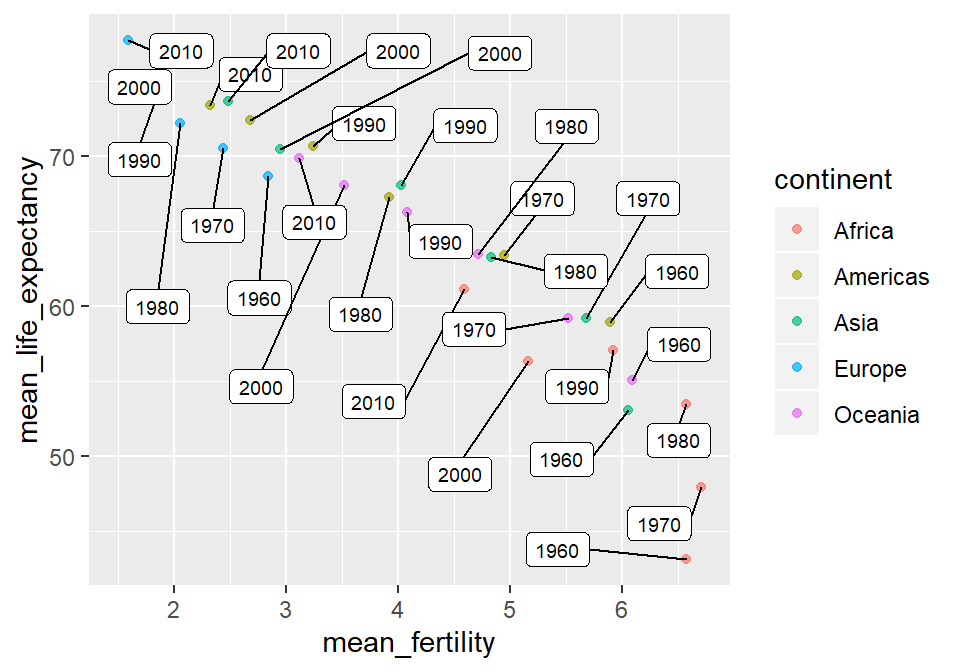

```r
labels_plot
```

## 7. Displaying a model / relationship that represents the data (and not show the actual data itself)

```r
## Model
lm <- gapminder %>% lm(formula = life_expectancy ~ fertility)

correlation <- cor.test(x = gapminder$fertility, y = gapminder$life_expectancy, method = "pearson")

# save predictions of the model in the new data frame
# together with variable you want to plot against
predicted_df <- data.frame(gapminder_pred = predict(lm, gapminder),
                           fertility = gapminder$fertility)
```

## Add model to plot

```r
model_plot <- gapminder %>%
  ggplot(aes(x = fertility,
             y = life_expectancy)) +
#  geom_point(alpha = 0.03) +
  geom_line(data = predicted_df, aes(x = fertility,
                                     y = gapminder_pred),
            colour = "darkred", size = 1)
```

## Plot

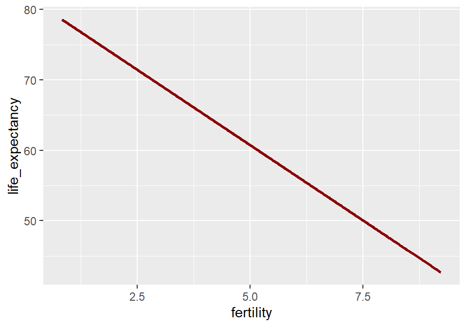

```r
model_plot
```

## Plotting statistics to the graph with the `{ggpubr}` package

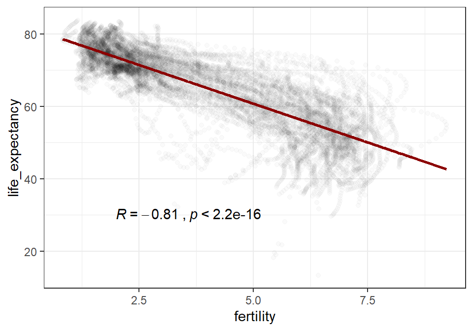

## Using a smoother `geom_smooth` to display potential relationships

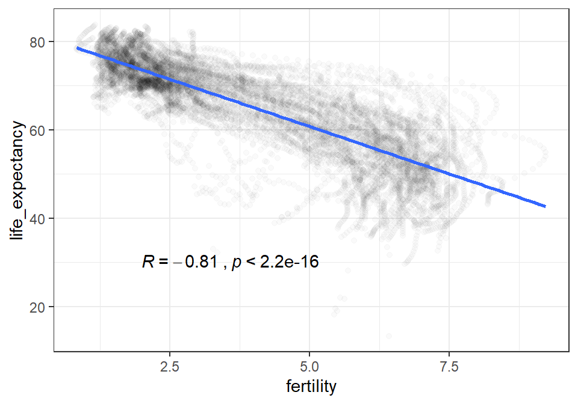

```r
gapminder %>%
  ggplot(aes(x = fertility,
             y = life_expectancy)) +
  geom_point(alpha = 0.02) +
  geom_smooth(method = "lm") +
  stat_cor(method = "pearson", label.x = 2, label.y = 30) +
  theme_bw()
```

## Recap **Discuss with your neighbour**

Which tricks can we use to reduce the dimensionality of the plotted data (prevent overpltting)?

Try listing at least 6 methods:

## Relation between `gdp`, Gross Domestic Product and `infant_mortality` rate.

https://en.wikipedia.org/wiki/Gross_domestic_product Wikipedia: Gross Domestic Product (GDP) is a monetary measure of the market value of all the final goods and services produced in a period of time, often annually or quarterly. Nominal GDP estimates are commonly used to determine the economic performance of a whole country or region, and to make international comparisons.

```r
gdp_infant_plot <- gapminder %>%
  dplyr::filter(continent == "Europe" | continent == "Africa") %>%
  ggplot(aes(x = gdp,
             y = infant_mortality)) +
  geom_point()
```

## Plot

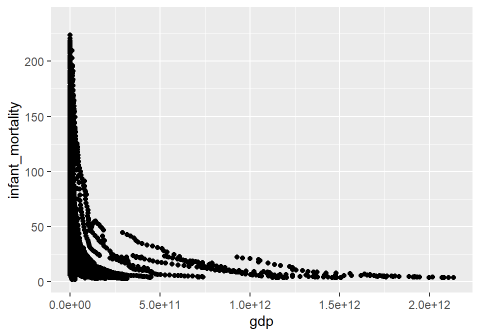

```r
gdp_infant_plot
```

## Adding a bit of colour

The figure above does not provide any clue on a possible difference between Europe and Africa, nor does it convey any information on trends over time.

```r
colour_to_continent <- gapminder %>%
  dplyr::filter(continent == "Europe" | continent == "Africa") %>%
  ggplot(aes(x = gdp,
             y = infant_mortality)) +
  geom_point(aes(colour = continent))
```

## Plot

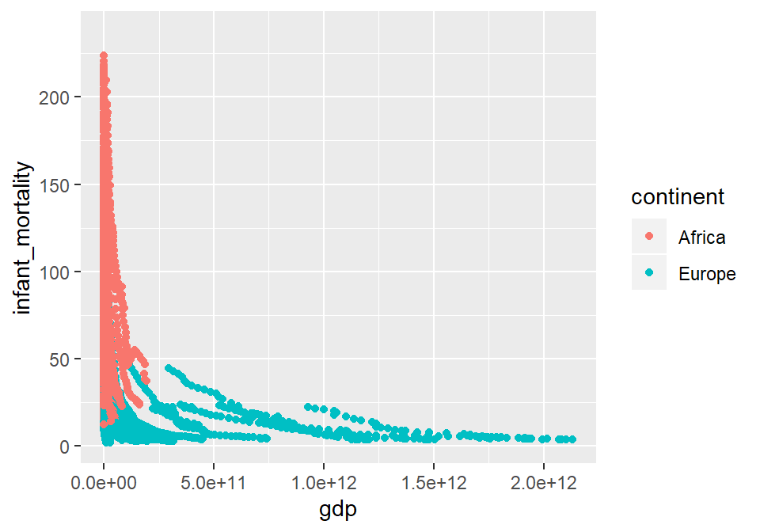

```r
colour_to_continent
```

## Adding facets

Let’s investigate whether things have improved over time. We compare 1960 to 2010 by using a panel of two figures. Adding simply `facet_wrap( ~ facetting_variable)` will do the trick.

## **Discuss with your neighbour:**

Without looking ahead try to contruct a plot that conveys information on the `gdp` per continent, over time. Try to recycle some of the examples above.

```r
facets_gdp_infant <- gapminder %>%
  dplyr::filter(continent == "Europe" | continent == "Africa",
                year == "1960" | year == "2010") %>%
  ggplot(aes(x = gdp,
             y = infant_mortality)) +
  geom_point(aes(colour = continent)) +
  facet_wrap(~ year) +
  theme(axis.text.x = element_text(angle = -90, hjust = 1))
```

## Plot

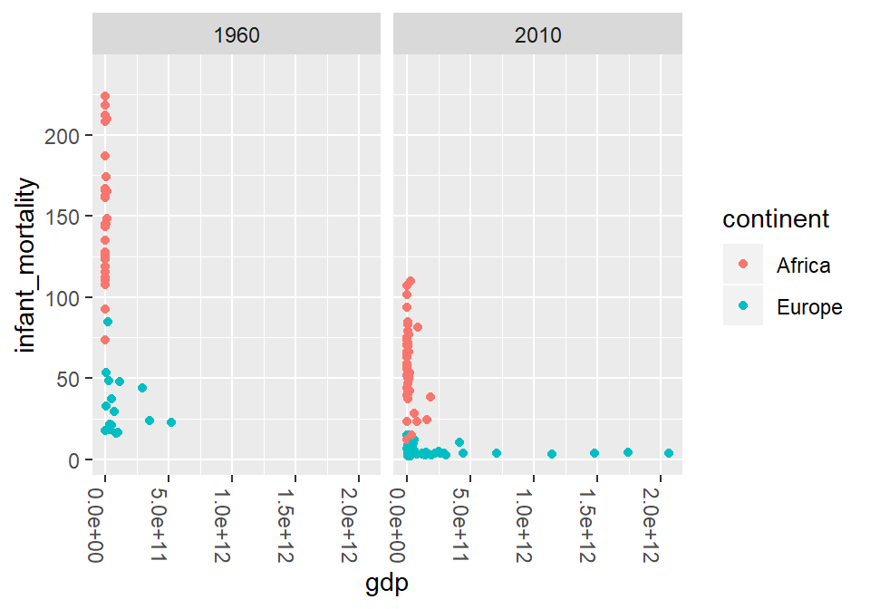

```r
facets_gdp_infant
```

## Mapping to continuous variables

So far we have been mapping colours and shapes to categorical variables. You can also map to continuous variables though.

```r
continuous <- gapminder %>%
  dplyr::filter(country == "Netherlands" |
                country == "China" |
                country == "India") %>%
  dplyr::filter(year %in% years) %>%
  ggplot(aes(x = year,
         y = life_expectancy)) +
  geom_point(aes(size = population, colour = country)) +
  guides(colour = guide_legend(override.aes = list(alpha = 1))) +
  geom_line(aes(group = country)) +
  theme_bw()
```

## Plot

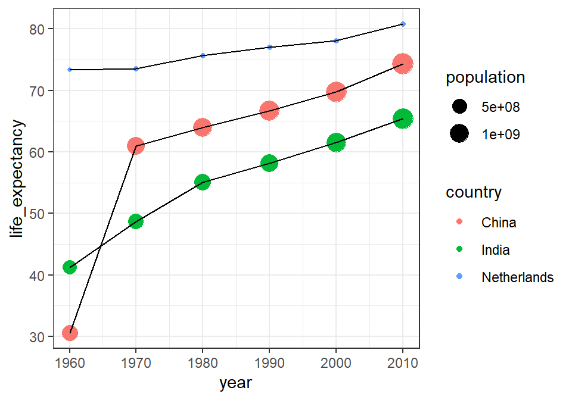

```r
continuous
```

## **Discuss with your neighbour**

Try plotting the `infant_mortality` against the filtered years for the same countries as the code above (Netherlands, India, China), recycling some of the code above. Discuss the resulting graph in the light of the life_expectancy graph, what do you think about the the developments in China?

Want to know more? see: https://www.ncbi.nlm.nih.gov/pmc/articles/PMC4331212/ Babxiarz, 2016

## **Discuss with your neighbour**

Analyze the following code chunk: try running line by line to see what happens:

- How many observations are we plotting here?
- How many variables are we plotting?
- Try adding or removing variables to the `group_by()` statement, what happens if you do?

## Summarize per continent and sum population

```r
population_plot <- gapminder %>%
  dplyr::group_by(continent, year) %>%
  dplyr::filter(year %in% years) %>%
  summarise(sum_population = sum(population)) %>%
  ggplot(aes(x = year,
             y = sum_population)) +
    geom_point(aes(colour = continent)) +
    geom_line(aes(group = continent,
                  colour = continent))
```

## Plot

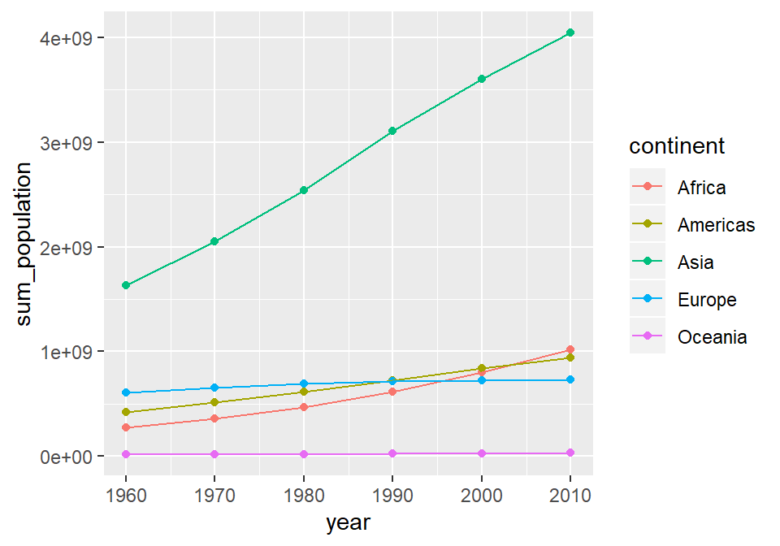

```r
population_plot
```

## Ranking data

```r
ranking_plot <- gapminder %>%
  dplyr::filter(continent == "Europe",
                year == 2010) %>%
  ggplot(aes(x = reorder(as_factor(country), population),
             y = log10(population))) +
  geom_point() +
  ylab("log10(Population)") +
  xlab("Country") +
  coord_flip() +
  geom_point(data = filter(gapminder %>%
  dplyr::filter(continent == "Europe",
                year == 2010), population >= 1e7), colour = "red")
```

## Plot

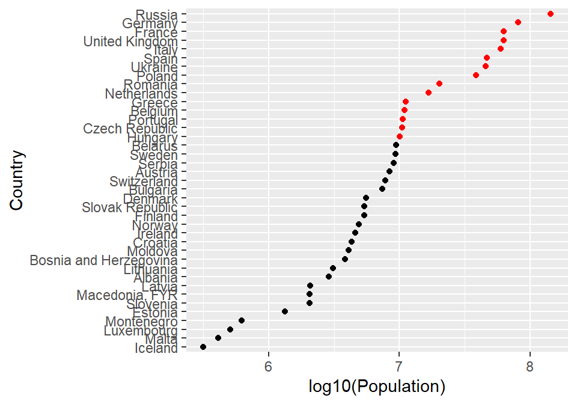

```r
ranking_plot
```

## Let’s look at a time series

We filter for “Americas” and “Oceania” and look at `life_expectancy` over the years.

```r
## without summarizing for countries
gapminder$continent %>% as_factor() %>% levels()
```

```
## [1] "Africa"   "Americas" "Asia"     "Europe"   "Oceania"
```

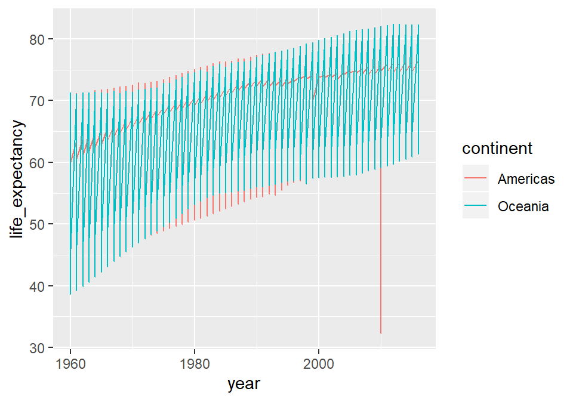

```r
gapminder %>%
  dplyr::filter(continent == "Americas" | continent == "Oceania") %>%
  ggplot(aes(x = year,
             y = life_expectancy)) +
  geom_line(aes(group = continent,
                colour = continent))
```

**Obviously something went wrong here. Please, discuss with your neighbour what you think happened or needs to be done to fix this (without looking ahead ;-) )**

## Grouping

We can see what happened if we plot individual datapoints

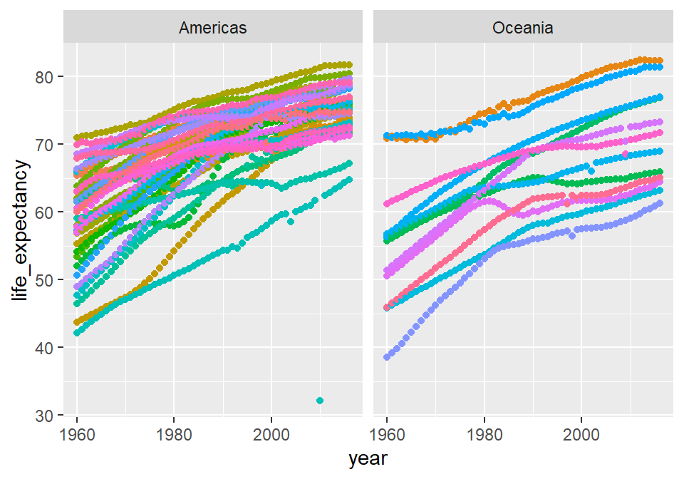

```r
gapminder %>%
  dplyr::filter(continent == "Americas" | continent == "Oceania") %>%
  ggplot(aes(x = year,
             y = life_expectancy)) +
  geom_point(aes(colour = country)) +
  theme(legend.position="none") +
  facet_wrap( ~ continent) +
  theme(legend.position="none")
```

## Summarizing time series data

```r
gapminder$continent %>% as_factor() %>% levels()
```

```
## [1] "Africa"   "Americas" "Asia"     "Europe"   "Oceania"
```

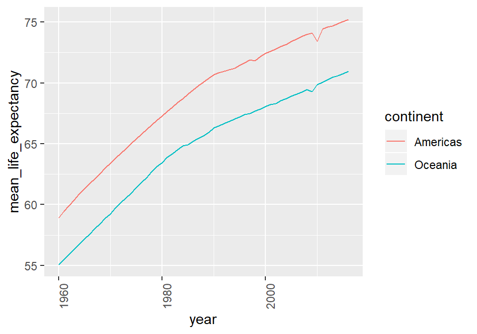

```r
gapminder %>%
  dplyr::filter(continent == "Americas" | continent == "Oceania") %>%
  group_by(continent, year) %>%
  summarise(mean_life_expectancy = mean(life_expectancy)) %>%
  ggplot(aes(x = year,
             y = mean_life_expectancy)) +
  geom_line(aes(group = continent,
                colour = continent)) +
  theme(axis.text.x = element_text(angle = 90, hjust = 1))
```

## Statistical proof?

```r
df <- gapminder %>%
  dplyr::filter(continent == "Americas" | continent == "Oceania") %>%
  group_by(continent, year)

model <- aov(data = df, life_expectancy ~ continent * year)
anova(model)
```

```
## Analysis of Variance Table
##
## Response: life_expectancy
##                  Df Sum Sq Mean Sq  F value Pr(>F)
## continent         1   8982    8982  269.104 <2e-16 ***
## year              1  58606   58606 1755.931 <2e-16 ***
## continent:year    1      9       9    0.278 0.5981
## Residuals      2732  91183      33
## ---
## Signif. codes:  0 '***' 0.001 '**' 0.01 '*' 0.05 '.' 0.1 ' ' 1
```

Some remarks on the above Two-way ANOVA:

- Repeated measures / multilevel models might be more appropriate here (paired / nested designs)
- We did not perform any check on assumptions
- We performed our analysis on only part of the data

## One more option: categorical values and “jitter”

Sometimes you have overlapping plots and adding transparency with `alpha()` or mapping colour to underlying categorical values is not working because there are simple to many points overlapping

Let’s look at an example

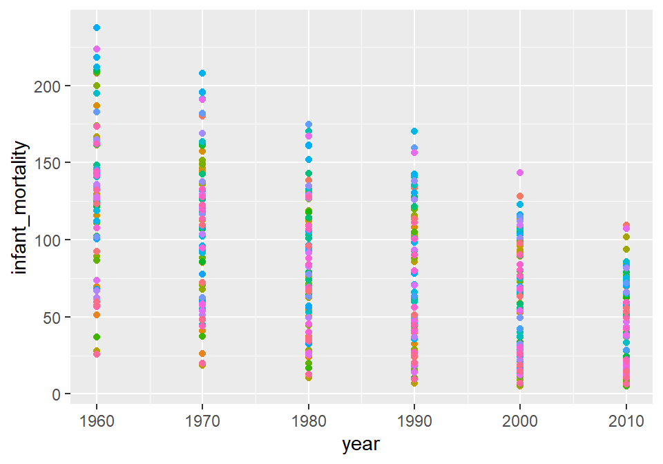

```r
gapminder %>%
  dplyr::filter(continent == "Americas" |
                continent == "Africa") %>%
  group_by(continent) %>%
  dplyr::filter(year %in% years) %>%
  ggplot(aes(x = year,
             y = infant_mortality)) +
  geom_point(aes(colour = country)) +
  theme(legend.position="none")
```

In such cases it can be helpfull to add some noise to the points (`position = "jitter"`) to reduce overlapping. This can be a powerfull approach, especially when combined with setting `alpha()`

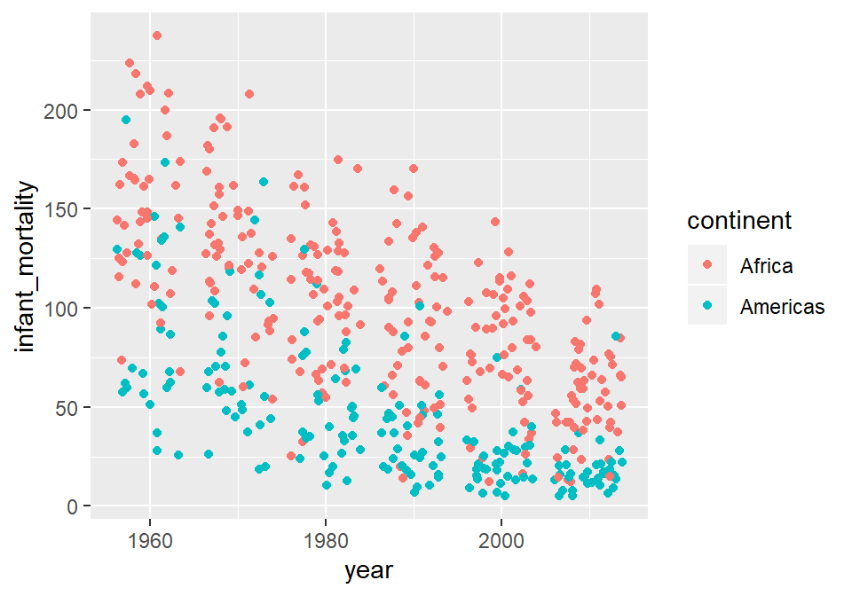

```r
gapminder %>%
  dplyr::filter(continent == "Americas" |
                continent == "Africa") %>%
  dplyr::filter(year %in% years) %>%
    group_by(continent) %>%
  ggplot(aes(x = year,
             y = infant_mortality)) +
  geom_point(aes(colour = continent), position = "jitter")
```

## Bar chart

It would be nice to know what the mean child mortality is for both continents

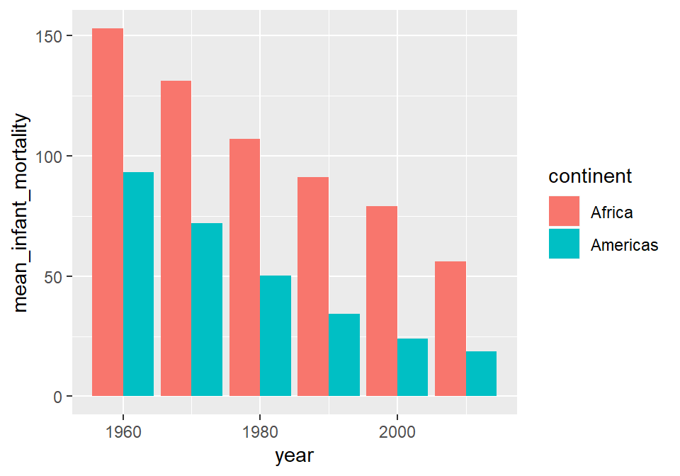

```r
gapminder %>%
  dplyr::filter(continent == "Americas" |
                continent == "Africa") %>%
  dplyr::filter(year %in% years) %>%
  group_by(continent, year) %>%
  summarise(mean_infant_mortality = mean(infant_mortality, na.rm = TRUE)) %>%
  ggplot(aes(x = year,
             y = mean_infant_mortality)) +
  geom_col(aes(fill = continent), position = "dodge")
```

## Adding summary data to an existing plot

Now that we have the mean infant mortality for each year for the two continents, let’s add that data to the previous dot plot where we used jitter

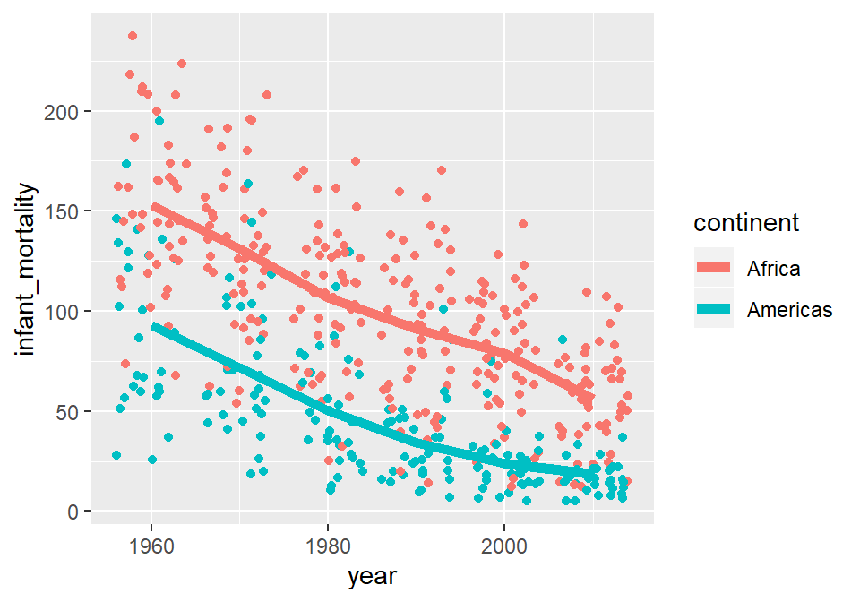

```r
mean_inf_mort <- gapminder %>%
  dplyr::filter(continent == "Americas" |
                continent == "Africa") %>%
  dplyr::filter(year %in% years) %>%
  group_by(continent, year) %>%
  summarise(mean_infant_mortality = mean(infant_mortality, na.rm = TRUE))

gapminder %>%
  dplyr::filter(continent == "Americas" |
                continent == "Africa") %>%
  dplyr::filter(year %in% years) %>%
    group_by(continent) %>%
  ggplot(aes(x = year,
             y = infant_mortality)) +
  geom_point(aes(colour = continent), position = "jitter") +

## summary data added to previous
  geom_line(data = mean_inf_mort, aes(x = year,
                                      y = mean_infant_mortality,
                                      colour = continent),  size = 2)
```

## Filter data from a graph

In the figure above we can observe a number of countries in ‘Americas’ continent that have a child mortality that are above the average (over the years) of ‘Africa’. Which countries are this?

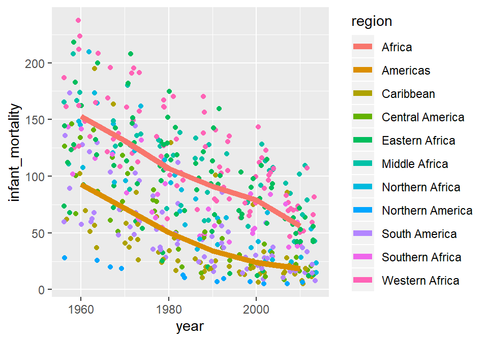

```r
library(ggiraph)

gapminder$country <-
  str_replace_all(string = gapminder$country,
                pattern = "'",
                replacement = "_")


interactive_inf_mort <- gapminder %>%
  dplyr::filter(continent == "Americas" |
                continent == "Africa") %>%
  dplyr::filter(year %in% years) %>%
    group_by(region, country) %>%
  ggplot(aes(x = year,
             y = infant_mortality)) +

  geom_point_interactive(aes(tooltip = country, colour = region), position = "jitter") +

#  geom_point(aes(colour = continent), position = "jitter") +

## summary data added to previous
 geom_line(data = mean_inf_mort, aes(x = year,
                                      y = mean_infant_mortality,
                                      colour = continent, group = continent),  size = 2
            )

interactive_inf_mort
```

```r
gapminder$country %>% as_factor() %>% levels()
```

```
##   [1] "Albania"                        "Algeria"
##   [3] "Angola"                         "Antigua and Barbuda"
##   [5] "Argentina"                      "Armenia"
##   [7] "Aruba"                          "Australia"
##   [9] "Austria"                        "Azerbaijan"
##  [11] "Bahamas"                        "Bahrain"
##  [13] "Bangladesh"                     "Barbados"
##  [15] "Belarus"                        "Belgium"
##  [17] "Belize"                         "Benin"
##  [19] "Bhutan"                         "Bolivia"
##  [21] "Bosnia and Herzegovina"         "Botswana"
##  [23] "Brazil"                         "Brunei"
##  [25] "Bulgaria"                       "Burkina Faso"
##  [27] "Burundi"                        "Cambodia"
##  [29] "Cameroon"                       "Canada"
```

[output cut: 78 more lines]

```r
ggiraph(ggobj = interactive_inf_mort)
```

[interactive chart not shown]

## A more complicated example (for showing the capabilities of ggplot2)

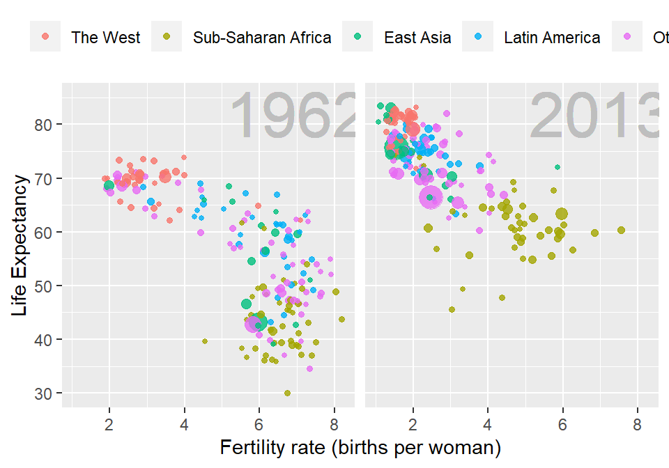

```r
west <- c("Western Europe","Northern Europe","Southern Europe",
          "Northern America","Australia and New Zealand")

gapminder <- gapminder %>%
  mutate(group = case_when(
    region %in% west ~ "The West",
    region %in% c("Eastern Asia", "South-Eastern Asia") ~ "East Asia",
    region %in% c("Caribbean", "Central America", "South America") ~ "Latin America",
    continent == "Africa" & region != "Northern Africa" ~ "Sub-Saharan Africa",
    TRUE ~ "Others"))
gapminder <- gapminder %>%
  mutate(group = factor(group, levels = rev(c("Others", "Latin America", "East Asia","Sub-Saharan Africa", "The West"))))

filter(gapminder, year%in%c(1962, 2013) & !is.na(group) &
         !is.na(fertility) & !is.na(life_expectancy)) %>%
  mutate(population_in_millions = population/10^6) %>%
  ggplot( aes(fertility, y=life_expectancy, col = group, size = population_in_millions)) +
  geom_point(alpha = 0.8) +
  guides(size=FALSE) +
  theme(plot.title = element_blank(), legend.title = element_blank()) +
  coord_cartesian(ylim = c(30, 85)) +
  xlab("Fertility rate (births per woman)") +
  ylab("Life Expectancy") +
  geom_text(aes(x=7, y=82, label=year), cex=12, color="grey") +
  facet_grid(. ~ year) +
  theme(strip.background = element_blank(),
        strip.text.x = element_blank(),
        strip.text.y = element_blank(),
   legend.position = "top")
```

# Optional (Data Distributions & Outliers)

## Detecting outliers

For this part we use a different and more simple dataset This dataset contains 1192 observations on self-reported:

- `height` (inch)
- `earn` ($)
- `sex` (gender)
- `ed` (currently unannotated)
- `age` (years)
- `race`

```r
heights_data <- read_csv(file = here::here("data",
                                          "heights_outliers.csv"))

heights_data
```

```
## # A tibble: 1,192 x 6
##     earn height sex       ed   age race
##    <dbl>  <dbl> <chr>  <dbl> <dbl> <chr>
##  1 50000   74.4 male      16    45 white
##  2 60000   65.5 female    16    58 white
##  3 30000   63.6 female    16    29 white
##  4 50000   63.1 female    16    91 other
##  5 51000   63.4 female    17    39 white
##  6  9000   64.4 female    15    26 white
##  7 29000   61.7 female    12    49 white
##  8 32000   72.7 male      17    46 white
##  9  2000   72.0 male      15    21 hispanic
## 10 27000   72.2 male      12    26 white
## # ... with 1,182 more rows
```

## Data characteristics

We will focus on the variable `height` here

```r
summary_heights_data <- heights_data %>%
  group_by(sex, age) %>%
  summarise(mean_height = mean(height, na.rm = TRUE),
            min_height = min(height),
            max_height = max(height)) %>%
  arrange(desc(mean_height))

summary_heights_data[c(1:4),]
```

```
## # A tibble: 4 x 5
## # Groups:   sex [2]
##   sex      age mean_height min_height max_height
##   <chr>  <dbl>       <dbl>      <dbl>      <dbl>
## 1 female    55       141.        61.9      664.
## 2 male      39       134.        66.6      572.
## 3 male      55        73.2       71.7       74.8
## 4 male      91        73.1       73.1       73.1
```

From the above summary we can conclude that there are two outliers (presumably entry errors).

**Calculate the height in meters for each outlier in the `Console`** 1 inch = 0,0254 meters

**Please discuss the solution with your neighbour**

## Checking the frequency distribution

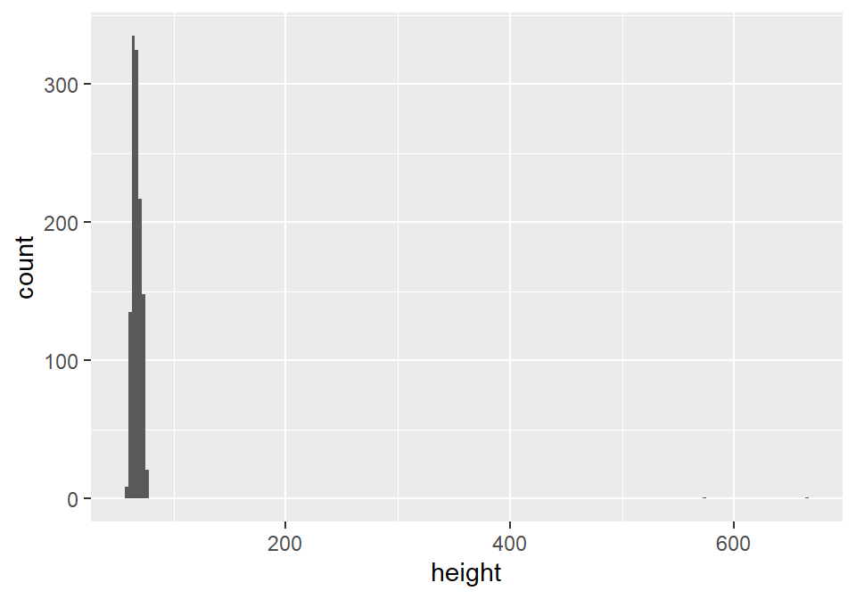

```r
heights_data %>%
  ggplot(aes(x = height)) +
  geom_histogram(aes(stat = "identity"), bins = 200)
```

This distribution looks odd. When you see a large x-axis with no data plotted on it, it usually means there is an outlier. If you look carefully, you will spot two outliers around 600

## Boxplots to detect outliers

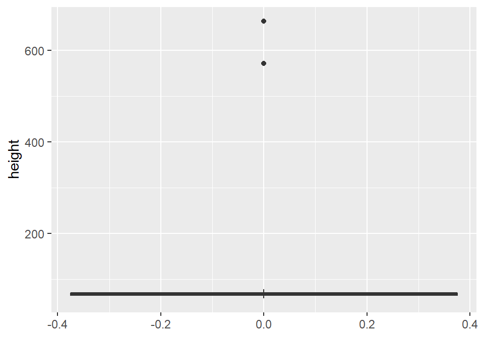

```r
heights_data %>%
  ggplot(aes(y = height)) +
  geom_boxplot()
```

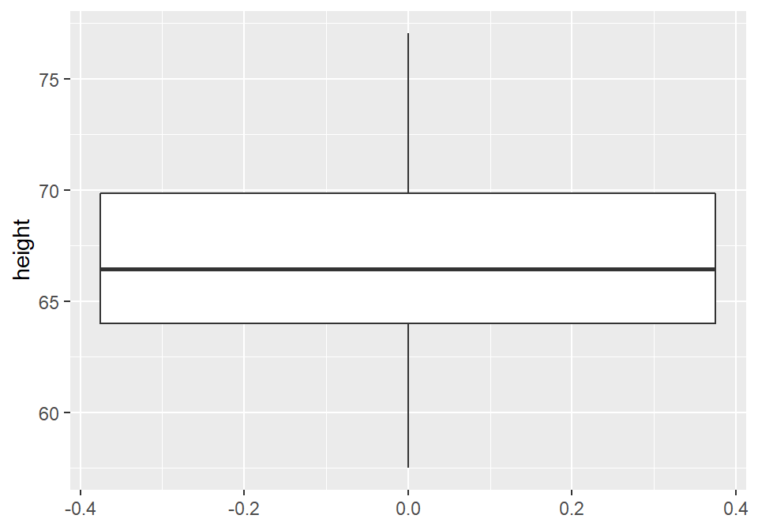

```r
heights_data %>%
  dplyr::filter(height < 100) %>%
  ggplot(aes(y = height)) +
  geom_boxplot()
```

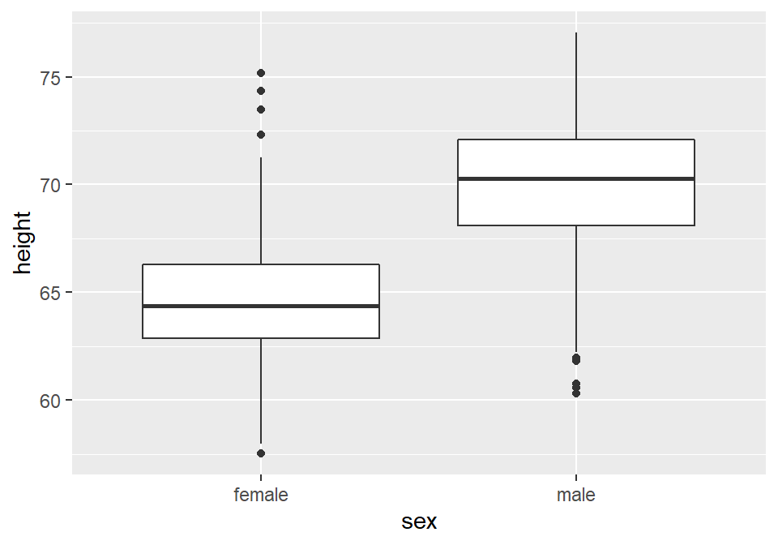

```r
## by sex

heights_data %>%
  dplyr::filter(height < 100) %>%
  ggplot(aes(y = height, x = sex)) +
  geom_boxplot()
```